# Assignment 3

Kat and Tim

## Missing Values Summary

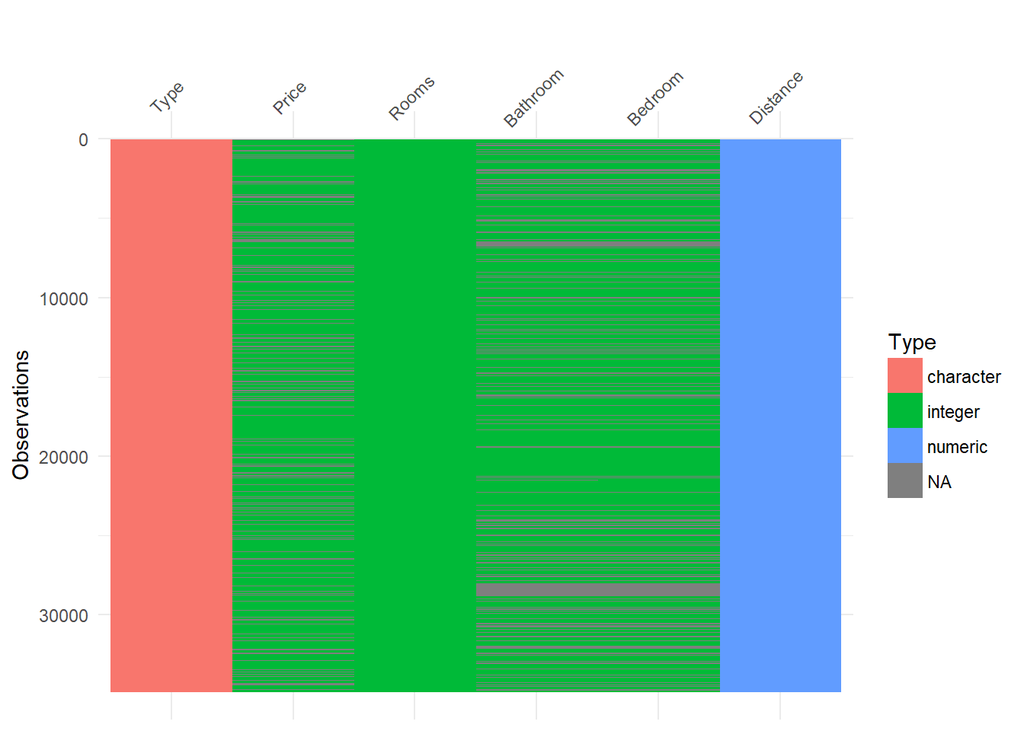

```r
library(tidyverse)
library(visdat)
library(naniar)
library(broom)
housing <- read.csv("data/Melbourne_housing_FULL.csv") %>%
  select(Price, Rooms, Type, Distance, Bedroom2, Bathroom) %>%
  mutate(Type = ifelse(Type == "u", "Unit", ifelse(Type == "h", "House", ifelse(Type == "t", "Townhouse", NA)))) %>%
  mutate(Distance = as.character(Distance)) %>% mutate(Distance = as.numeric(Distance)) %>%
  mutate(Bedroom = as.integer(Bedroom2)) %>%
  select(-Bedroom2)
vis_dat(housing)
```

```r
miss_summary(housing)
```

```
## # A tibble: 1 x 7
##   miss_df_prop miss_var_prop miss_case_prop miss_case_table miss_var_table
##          <dbl>         <dbl>          <dbl> <list>          <list>
## 1        0.115         0.667          0.403 <tibble [4 x 3~ <tibble [5 x ~
## # ... with 2 more variables: miss_var_summary <list>,
## #   miss_case_summary <list>
```

```r
housing_shadow <- bind_shadow(housing)
```

The summary of missing values indicates that around 40% of the cases are missing values for one or more variables, and 11.5% of the total observations are missing. It also shows that two thirds of the variables contain missing values, with the table confirming that Price, Bathroom and Bedroom are the variables with significant missing values, meaning we need to impute values for these variables. One option is to impute the values using the means or medians of the variables, however we can likely make a better prediction of the missing values using the relationship between Bedroom/Bathroom and the other variables in the dataset. Therefore, we are imputing the missing values for Bathroom and Bedroom using a linear regression model of these variables on the other variables in the dataset. We do not include Bathroom in the model for Bedroom and vice-versa, as the table shows that the cases missing values for Bedroom are also missing values for Bathroom, meaning we will not be able to predict missing value of one from the other.

```r
bathroom_imputation <- lm(housing, formula=Bathroom ~ Price + Rooms + Type + Distance)
summary(bathroom_imputation)
```

```
##
## Call:
## lm(formula = Bathroom ~ Price + Rooms + Type + Distance, data = housing)
##
## Residuals:
##     Min      1Q  Median      3Q     Max
## -2.8386 -0.3856 -0.0240  0.3238  6.2277
##
## Coefficients:
##                 Estimate Std. Error t value Pr(>|t|)
## (Intercept)   -1.766e-01  1.675e-02  -10.54   <2e-16 ***
## Price          2.891e-07  7.011e-09   41.24   <2e-16 ***
## Rooms          4.113e-01  5.103e-03   80.60   <2e-16 ***
## TypeTownhouse  4.633e-01  1.405e-02   32.97   <2e-16 ***
## TypeUnit       2.997e-01  1.186e-02   25.27   <2e-16 ***
## Distance       9.528e-03  6.166e-04   15.45   <2e-16 ***
## ---
## Signif. codes:  0 '***' 0.001 '**' 0.01 '*' 0.05 '.' 0.1 ' ' 1
##
## Residual standard error: 0.5234 on 20794 degrees of freedom
##   (14057 observations deleted due to missingness)
## Multiple R-squared:  0.4424, Adjusted R-squared:  0.4423
## F-statistic:  3300 on 5 and 20794 DF,  p-value: < 2.2e-16
```

```r
bedroom_imputation <- lm(housing, formula=Bedroom ~ Price + Rooms + Type + Distance)
summary(bedroom_imputation)
```

```
##
## Call:
## lm(formula = Bedroom ~ Price + Rooms + Type + Distance, data = housing)
##
## Residuals:
##     Min      1Q  Median      3Q     Max
## -3.9607 -0.0086  0.0120  0.0346 17.0044
##
## Coefficients:
##                 Estimate Std. Error t value Pr(>|t|)
## (Intercept)    7.399e-02  8.666e-03   8.539  < 2e-16 ***
## Price          1.899e-08  3.626e-09   5.237 1.65e-07 ***
## Rooms          9.548e-01  2.640e-03 361.627  < 2e-16 ***
## TypeTownhouse -8.293e-03  7.269e-03  -1.141   0.2539
## TypeUnit      -1.436e-02  6.139e-03  -2.339   0.0193 *
## Distance       2.785e-03  3.190e-04   8.731  < 2e-16 ***
## ---
## Signif. codes:  0 '***' 0.001 '**' 0.01 '*' 0.05 '.' 0.1 ' ' 1
##
## Residual standard error: 0.2709 on 20800 degrees of freedom
##   (14051 observations deleted due to missingness)
## Multiple R-squared:  0.9196, Adjusted R-squared:  0.9195
## F-statistic: 4.756e+04 on 5 and 20800 DF,  p-value: < 2.2e-16
```

```r
summary(predict(bathroom_imputation))
```

```
##    Min. 1st Qu.  Median    Mean 3rd Qu.    Max.
##  0.3483  1.3361  1.5031  1.5917  1.8846  8.0142
```

```r
summary(predict(bedroom_imputation))
```

```
##    Min. 1st Qu.  Median    Mean 3rd Qu.    Max.
##   1.024   2.045   2.989   3.046   3.940  15.493
```

```r
summary(housing)
```

```
##      Price              Rooms            Type              Distance
##  Min.   :   85000   Min.   : 1.000   Length:34857       Min.   : 0.00
##  1st Qu.:  635000   1st Qu.: 2.000   Class :character   1st Qu.: 6.40
##  Median :  870000   Median : 3.000   Mode  :character   Median :10.30
##  Mean   : 1050173   Mean   : 3.031                      Mean   :11.18
##  3rd Qu.: 1295000   3rd Qu.: 4.000                      3rd Qu.:14.00
##  Max.   :11200000   Max.   :16.000                      Max.   :48.10
##  NA's   :7610                                           NA's   :1
##     Bathroom         Bedroom
##  Min.   : 0.000   Min.   : 0.000
##  1st Qu.: 1.000   1st Qu.: 2.000
##  Median : 2.000   Median : 3.000
##  Mean   : 1.625   Mean   : 3.085
##  3rd Qu.: 2.000   3rd Qu.: 4.000
##  Max.   :12.000   Max.   :30.000
##  NA's   :8226     NA's   :8217
```

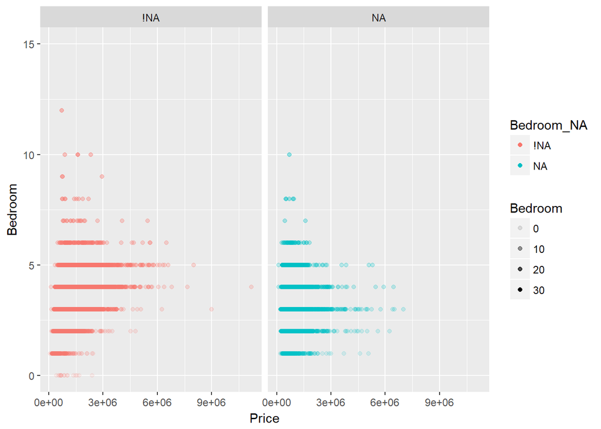

```r
housing_shadow <- housing_shadow %>%
  mutate(Bathroom = ifelse(is.na(Bathroom),round(predict(bathroom_imputation), digits=0),  Bathroom)) %>%
  mutate(Bedroom = ifelse(is.na(Bedroom),round(predict(bedroom_imputation), digits=0),  Bedroom)) %>%
  filter(complete.cases(Distance))
ggplot(housing_shadow, aes(x=Price,y=Bedroom,colour=Bedroom_NA,alpha=Bedroom)) +
  geom_point() +
  coord_cartesian(ylim=c(0,15)) +
  facet_wrap(~Bedroom_NA)
```

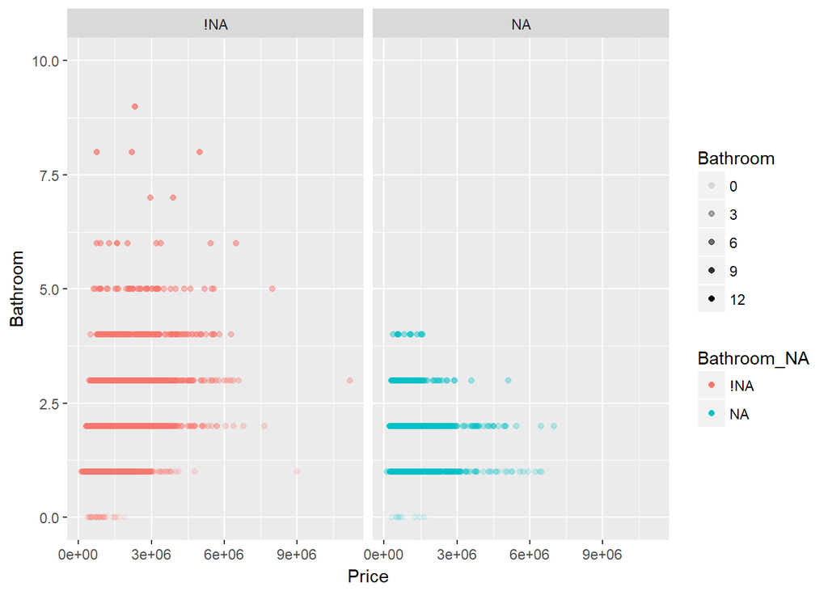

```r
ggplot(housing_shadow, aes(x=Price,y=Bathroom,colour=Bathroom_NA,alpha=Bathroom)) +
  geom_point() +
  coord_cartesian(ylim=c(0,10)) +
  facet_wrap(~Bathroom_NA)
```

Furthermore, the quartiles and means of the imputed values are not significantly dissimilar to those of the observations on these variables except that the maximums of the imputed values are significantly lower. The plots of the values also show that the impute values appear to fit in with the observed data without any outliers or irregular patterns.

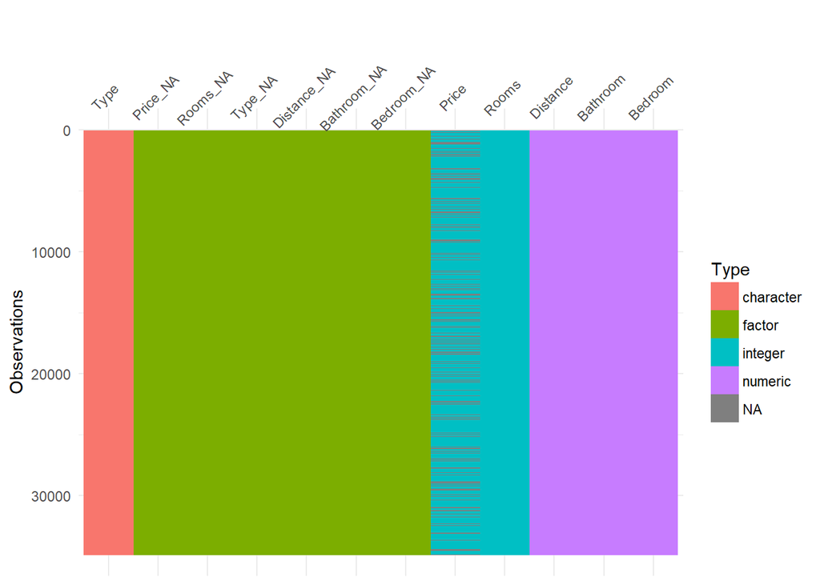

```r
vis_dat(housing_shadow)
```

```r
miss_summary(housing_shadow)
```

```
## # A tibble: 1 x 7
##   miss_df_prop miss_var_prop miss_case_prop miss_case_table miss_var_table
##          <dbl>         <dbl>          <dbl> <list>          <list>
## 1       0.0182        0.0833          0.218 <tibble [2 x 3~ <tibble [2 x ~
## # ... with 2 more variables: miss_var_summary <list>,
## #   miss_case_summary <list>
```

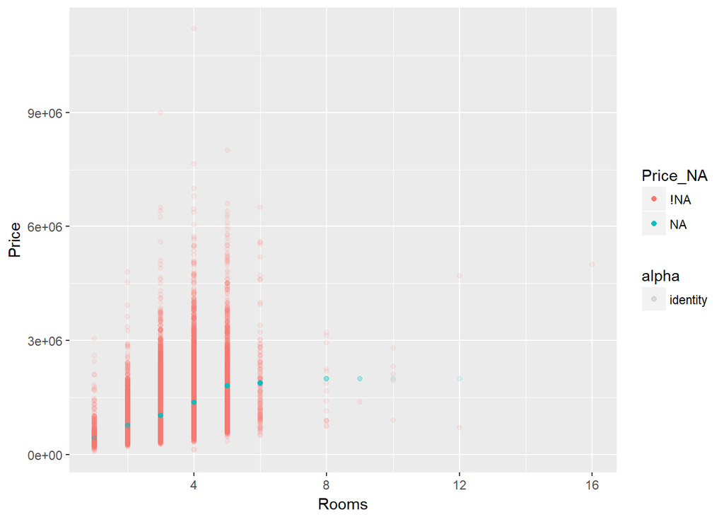

```r
r1 <- bind_shadow(housing) %>%
  filter(Rooms==1) %>%
  mutate(Price=ifelse(is.na(Price),mean(Price,na.rm=TRUE),Price))
r2 <- bind_shadow(housing) %>%
  filter(Rooms==2) %>%
  mutate(Price=ifelse(is.na(Price),mean(Price,na.rm=TRUE),Price))
r3 <- bind_shadow(housing) %>%
  filter(Rooms==3) %>%
  mutate(Price=ifelse(is.na(Price),mean(Price,na.rm=TRUE),Price))
r4 <- bind_shadow(housing) %>%
  filter(Rooms==4) %>%
  mutate(Price=ifelse(is.na(Price),mean(Price,na.rm=TRUE),Price))
r5 <- bind_shadow(housing) %>%
  filter(Rooms==5) %>%
  mutate(Price=ifelse(is.na(Price),mean(Price,na.rm=TRUE),Price))
r6 <- bind_shadow(housing) %>%
  filter(Rooms==6) %>%
  mutate(Price=ifelse(is.na(Price),mean(Price,na.rm=TRUE),Price))
r7plus <- bind_shadow(housing) %>%
  filter(Rooms>7) %>%
  mutate(Price=ifelse(is.na(Price),mean(Price,na.rm=TRUE),Price))
housing_shadow <- bind_rows(r1,r2,r3,r4,r5,r6,r7plus) %>%
  mutate(Bathroom = ifelse(is.na(Bathroom),round(predict(bathroom_imputation), digits=0),  Bathroom)) %>%
  mutate(Bedroom = ifelse(is.na(Bedroom),round(predict(bedroom_imputation), digits=0),  Bedroom)) %>%
  filter(complete.cases(Distance))
ggplot(housing_shadow,aes(x=Rooms,y=Price,colour=Price_NA,alpha="identity")) +
  geom_point()
```

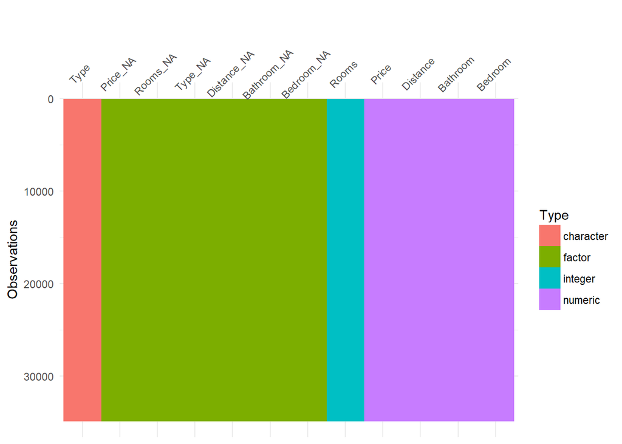

```r
vis_dat(housing_shadow)
```

```r
miss_summary(housing_shadow)
```

```
## # A tibble: 1 x 7
##   miss_df_prop miss_var_prop miss_case_prop miss_case_table miss_var_table
##          <dbl>         <dbl>          <dbl> <list>          <list>
## 1           0.            0.             1. <tibble [1 x 3~ <tibble [1 x ~
## # ... with 2 more variables: miss_var_summary <list>,
## #   miss_case_summary <list>
```

```r
housing <- housing_shadow %>% select(Price,Rooms,Type,Distance,Bathroom,Bedroom)
```

We see that the missings fit the existing data reasonably well and that now all missing values have been eliminated

#### Price and Number of Rooms

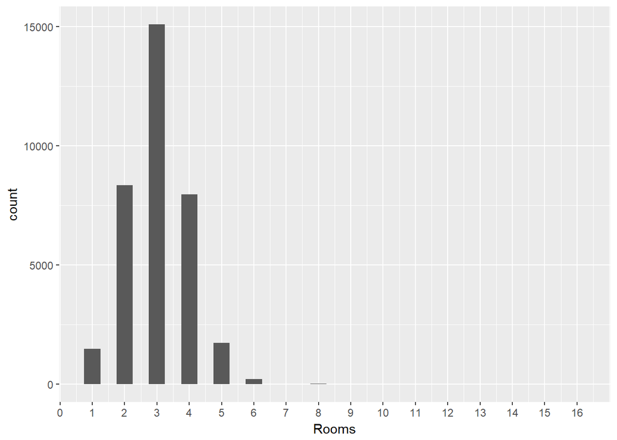

```r
ggplot(housing,aes(Rooms)) +
  scale_x_continuous(breaks = seq(0, 16, by = 1)) +
  geom_histogram(binwidth=0.5)
```

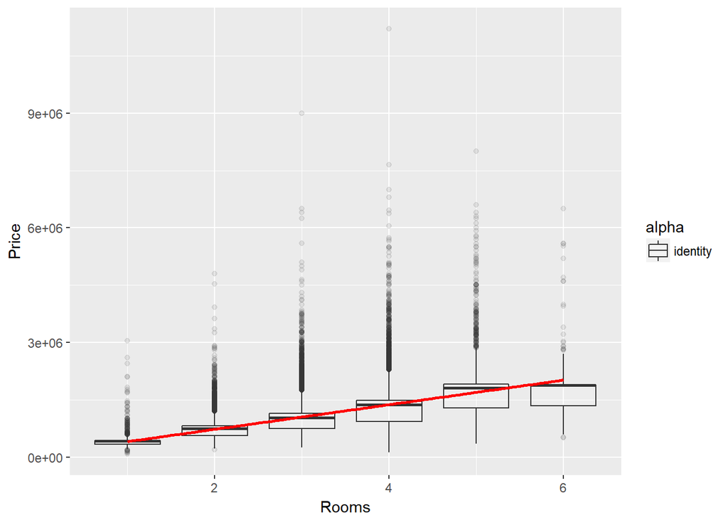

```r
ggplot(housing %>% filter(Rooms<7), aes(x=Rooms,y=Price)) +
  geom_boxplot(aes(group=Rooms,alpha="identity")) +
  stat_smooth(method=lm,colour="red")
```

For the variables involving number of rooms, we use boxplots as these variables are discrete rather than continuous, and with such a large number of observations boxplots give us a better indication of the density of the data. However, boxplots can be misleading in small sample sizes. Looking at the distribution of Rooms we then see that there are very few instances of Rooms greater than 6, meaning that these values may be inconsistent with the overall pattern due to such small sample sizes. Therefore, for the boxplot we plot only cases where the value of Rooms is less than 7, and we see a positive correlation between number of rooms and Price.

#### Price and Number of Bedrooms

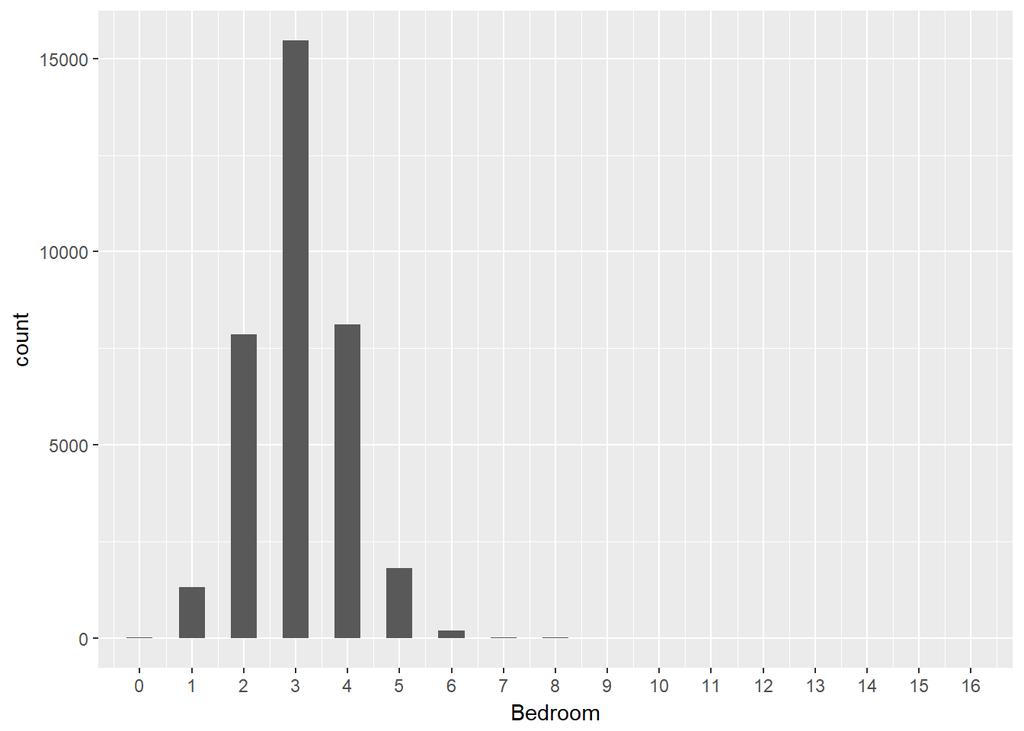

```r
ggplot(housing,aes(Bedroom)) +
  scale_x_continuous(breaks = seq(0, 16, by = 1)) +
  coord_cartesian(xlim=c(0,16)) +
  geom_histogram(binwidth=0.5)
```

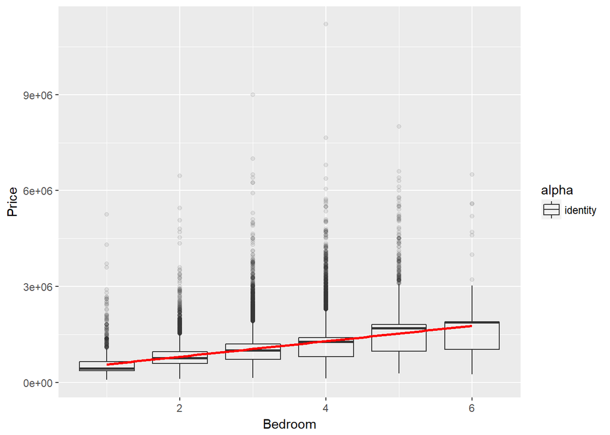

```r
ggplot(housing %>% filter(Bedroom<7,Bedroom>0), aes(x=Bedroom,y=Price)) +
  geom_boxplot(aes(group=Bedroom,alpha="identity")) +
  stat_smooth(method=lm,colour="red")
```

We see a similar pattern with the distribution of bedrooms, with there being very few cases of Bedroom being greater than 6. For the same reason we again only include cases where Bedroom is less than 7 in the boxplots, and again see a positive relationship between number of bedrooms and Price.

#### Price and Number of Bathrooms

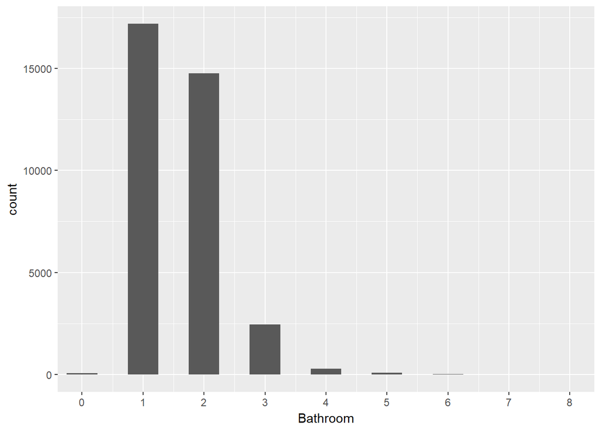

```r
ggplot(housing,aes(Bathroom)) +
  scale_x_continuous(breaks = seq(0, 8, by = 1)) +
  coord_cartesian(xlim=c(0,8)) +
  geom_histogram(binwidth=0.5)
```

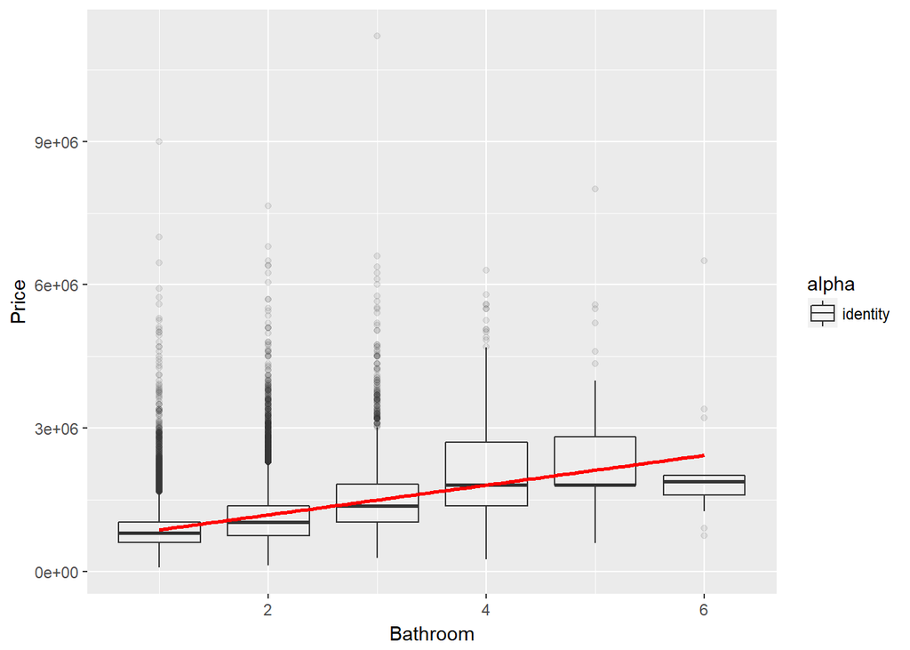

```r
ggplot(housing %>% filter(Bathroom<7,Bathroom>0), aes(x=Bathroom,y=Price)) +
  geom_boxplot(aes(group=Bathroom,alpha="identity")) +
  stat_smooth(method=lm,colour="red")
```

We see a similar pattern with the distribution of bathrooms, with there being very few cases of Bathroom being greater than 6. For the same reason we again only include cases where Bathroom is less than 7 in the boxplots, and again see a positive relationship between number of bathrooms and Price.

We want to determine which variables to include in our model. To minimize uncertainty in parameter estimates, associations between explanatory variables should be minimized. We examine the strength of the linear relationships between our explanatory variables using correlation:

```r
BathBedCorr <- cor(housing$Bedroom, housing$Bathroom)
RoomsBedCorr <- cor(housing$Bedroom,housing$Rooms)
DistanceBedCorr <- cor(housing$Bedroom,housing$Distance)

RoomsBathCorr <- cor(housing$Bathroom, housing$Rooms)
DistanceBathCorr <- cor(housing$Bathroom, housing$Distance)

DistanceRoomsCorr <- cor(housing$Rooms, housing$Distance)

Correlation_values <- c(BathBedCorr, RoomsBathCorr, DistanceBathCorr, RoomsBathCorr, DistanceBathCorr, DistanceRoomsCorr)
Correlation_values
```

```
## [1] 0.5733689 0.4917640 0.1106924 0.4917640 0.1106924 0.2725190
```

Next we plot scatterplots of our continuous explanatory variable against price to get an idea of the type of distribution or family of functions which is likely to be the most appropriate. We use geom_smooth to help us visualise the best curve/ fit. (Note: limits have been selected based on what can be considered reasonable and in order to allow geom_smooth to run).

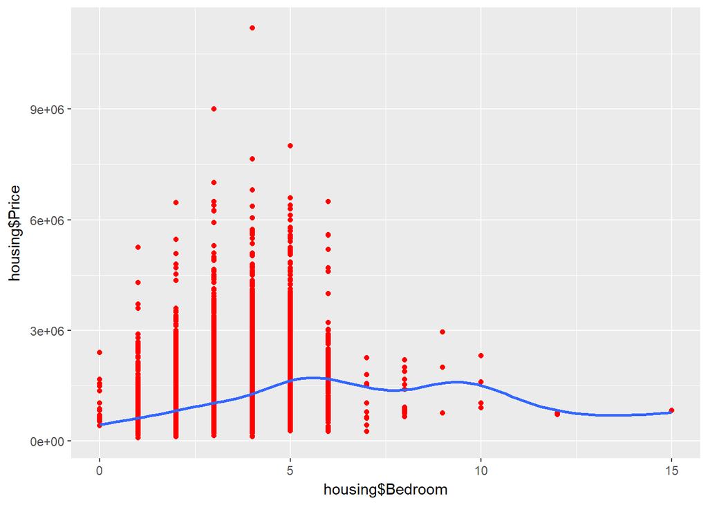

```r
ggplot(housing, aes(x=housing$Bedroom,y=housing$Price)) +
  geom_point(colour='red')+ geom_smooth(se=FALSE)+scale_x_continuous(limits = c(0, 15))
```

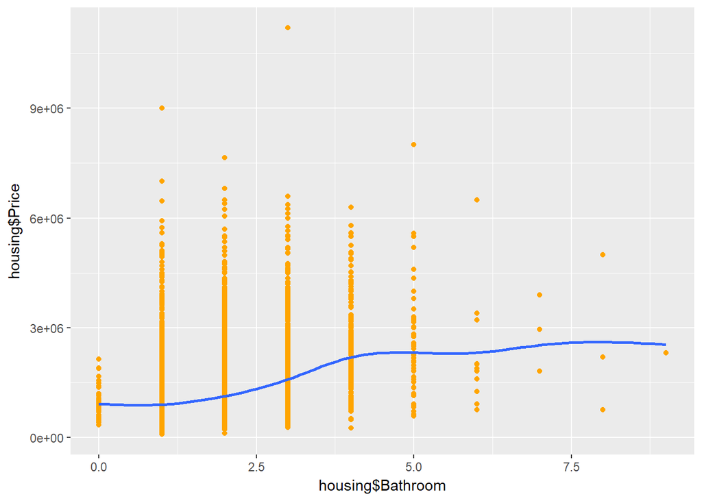

```r
ggplot(housing, aes(x=housing$Bathroom,y=housing$Price)) +
  geom_point(colour='orange')+ geom_smooth(se=FALSE)+scale_x_continuous(limits = c(0, 9))
```

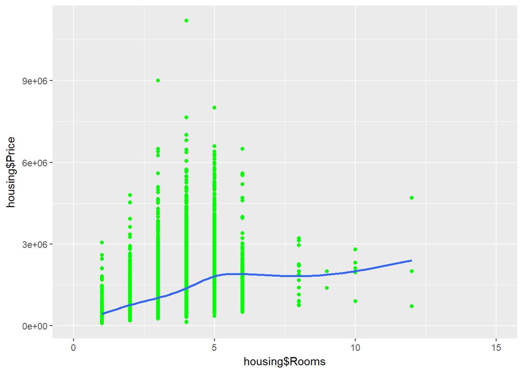

```r
ggplot(housing, aes(x=housing$Rooms,y=housing$Price)) +
  geom_point(colour='green')+ geom_smooth(se=FALSE)+scale_x_continuous(limits = c(0, 15))
```

## Models

We trial a series of different models starting with a level- level model:

```r
mod1 <- lm(data = housing, Price~Rooms+Bedroom+Bathroom+Distance)
tidy(mod1)
```

```
##          term  estimate std.error  statistic       p.value
## 1 (Intercept) 215399.81 9067.5385  23.755047 9.431590e-124
## 2       Rooms 347708.89 3839.3034  90.565619  0.000000e+00
## 3     Bedroom -33494.31 3991.0607  -8.392332  4.943441e-17
## 4    Bathroom 124927.73 4429.6156  28.202837 4.789936e-173
## 5    Distance -27123.58  380.8446 -71.219554  0.000000e+00
```

```r
glance(mod1)
```

```
##   r.squared adj.r.squared    sigma statistic p.value df    logLik     AIC
## 1 0.3760902     0.3760185 463401.8  5247.187       0  5 -503736.7 1007485
##       BIC     deviance df.residual
## 1 1007536 7.477076e+15       34819
```

```r
mod2 <- lm(data= housing, formula= Price~ Bedroom+ Bathroom +Distance)
tidy(mod2)
```

```
##          term  estimate std.error statistic       p.value
## 1 (Intercept) 444311.50 9679.4716  45.90245  0.000000e+00
## 2     Bedroom 184728.89 3536.4896  52.23510  0.000000e+00
## 3    Bathroom 180948.51 4875.4681  37.11408 9.879335e-296
## 4    Distance -21158.77  416.9472 -50.74687  0.000000e+00
```

```r
glance(mod2)
```

```
##   r.squared adj.r.squared    sigma statistic p.value df    logLik     AIC
## 1  0.229119     0.2290526 515091.4    3449.7       0  4 -507419.8 1014850
##       BIC     deviance df.residual
## 1 1014892 9.238412e+15       34820
```

With this model again all variables are deemed statistically significant and the regressor coefficients appear a lot more realistic, although still an overrepresentation. Given the magnitude of the coefficents the standard errors are also relatively small being approximately 2-3% the size of the coefficients implying tight confidence intervals. A major negative trade off is that the R squared value has decreased significantly to 0.23 emphasizing the significant impact the number of rooms has on house price leading us to believe that it would be better to continue to include this variable. Subsequently we next run a model including all variables as well as Type which will act as a dummy variable of dwelling type which we previously didn’t include:

```r
mod3 <- lm(data= housing, formula= Price~ Rooms + Bedroom + Bathroom + Distance + Type)
tidy(mod3)
```

```
##            term   estimate  std.error  statistic       p.value
## 1   (Intercept)  485708.68 11288.1269  43.028280  0.000000e+00
## 2         Rooms  279761.64  4171.0381  67.072425  0.000000e+00
## 3       Bedroom  -34763.24  3912.4328  -8.885325  6.672189e-19
## 4      Bathroom  145048.86  4371.5898  33.179888 1.073039e-237
## 5      Distance  -28612.73   374.6449 -76.372928  0.000000e+00
## 6 TypeTownhouse -186189.38  8296.0947 -22.443015 9.163434e-111
## 7      TypeUnit -272594.80  7375.0117 -36.961948 2.245307e-293
```

```r
glance(mod3)
```

```
##   r.squared adj.r.squared    sigma statistic p.value df    logLik     AIC
## 1 0.4028353     0.4027324 453373.8  3914.474       0  7 -502973.8 1005964
##       BIC     deviance df.residual
## 1 1006031 7.156557e+15       34817
```

Compared to model 1, the R squared value of model 3 has improved slightly from 0.38 in model 1 to 0.40. In order to determine whether the addition of this extra variable was meaningful (keeping in mind that additional variables will always lead to an increase in R squared), we use the adjusted R squared value as a fairer method of comparison. The adjusted R squared value in model 1 is 0.38 and 0.40 in model 3 - the same as R squared so we can conclude that it is beneficial including the Type variable in our model. After observing the scatterplots of the relationships between the individual x variables and y it appears that a log- level model will likely be a better fit for the data than a level- level model so we try this next:

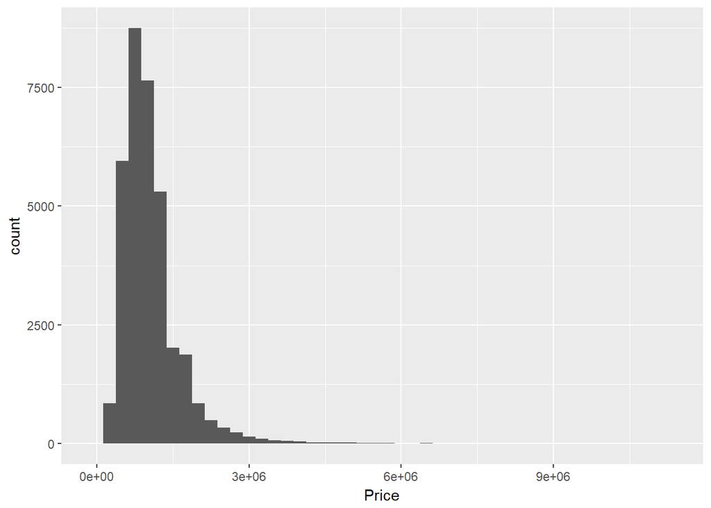

```r
ggplot(housing,aes(Price)) +
    geom_histogram(binwidth=250000)
```

```r
mod4 <- lm(data=housing, formula=log(Price) ~ Rooms+Bathroom+Bedroom+Distance+Type)
tidy(mod4)
```

```
##            term    estimate   std.error   statistic       p.value
## 1   (Intercept) 13.30381726 0.008464840 1571.656165  0.000000e+00
## 2         Rooms  0.24860165 0.003127815   79.480941  0.000000e+00
## 3      Bathroom  0.08685710 0.003278206   26.495315 3.640628e-153
## 4       Bedroom -0.02469379 0.002933889   -8.416743  4.016847e-17
## 5      Distance -0.02494265 0.000280942  -88.782209  0.000000e+00
## 6 TypeTownhouse -0.13346018 0.006221148  -21.452660 1.960268e-101
## 7      TypeUnit -0.34407422 0.005530438  -62.214637  0.000000e+00
```

```r
glance(mod4)
```

```
##   r.squared adj.r.squared     sigma statistic p.value df    logLik
## 1 0.5043765     0.5042911 0.3399799  5905.316       0  7 -11839.09
##        AIC      BIC deviance df.residual
## 1 23694.18 23761.84 4024.369       34817
```

From the histogram of the Price variable the distribution appears to be significantly positively skewed, suggesting that a log transformation may be appropriate. With this log-level model the R squared and adjusted R squared value have both increased to 0.50 which is the best we have seen thus far. All variables are deemed significant upon assessing the t-stat/ p-value but note the coefficients look very different to the coefficients in the previous models. With a log- level model we interpret the coefficients as signifing the effect of a one unit increase in x on the percentage increase or decrease in the variable y. For example, this model is suggesting that one additional bathroom will lead to an 8.7% increase in house price. We continue to use log in the following models but also consider the interactions which exist between the explanatory variables:

```r
mod5 <- lm(data=housing, log(Price) ~ Rooms+Bathroom+Bedroom+Distance*Type)
tidy(mod5)
```

```
##                     term    estimate    std.error   statistic
## 1            (Intercept) 13.35843016 0.0085879682 1555.482029
## 2                  Rooms  0.24447350 0.0030959991   78.964333
## 3               Bathroom  0.09000614 0.0032430463   27.753578
## 4                Bedroom -0.02480271 0.0029015821   -8.547997
## 5               Distance -0.02869462 0.0003079809  -93.170134
## 6          TypeTownhouse -0.31670449 0.0141278091  -22.417099
## 7               TypeUnit -0.53262812 0.0089774180  -59.329767
## 8 Distance:TypeTownhouse  0.01645761 0.0011782087   13.968335
## 9      Distance:TypeUnit  0.02065616 0.0007949065   25.985652
##         p.value
## 1  0.000000e+00
## 2  0.000000e+00
## 3 1.062086e-167
## 4  1.302669e-17
## 5  0.000000e+00
## 6 1.627251e-110
## 7  0.000000e+00
## 8  3.202878e-44
## 9 1.840847e-147
```

```r
glance(mod5)
```

```
##   r.squared adj.r.squared    sigma statistic p.value df    logLik      AIC
## 1 0.5155858     0.5154745 0.336123  4631.913       0  9 -11440.77 22901.54
##        BIC deviance df.residual
## 1 22986.12 3933.352       34815
```

## Residuals

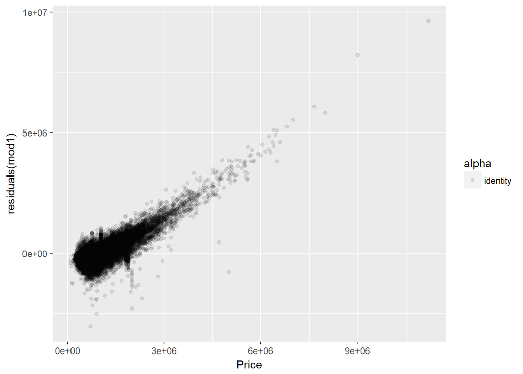

```r
ggplot(data=mod1, aes(x=Price,y=residuals(mod1),alpha="identity")) +
  geom_point()
```

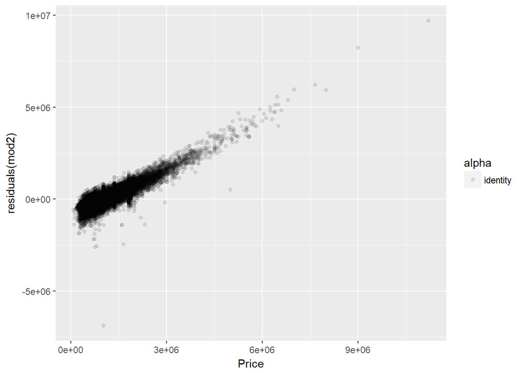

```r
ggplot(data=mod2, aes(x=Price,y=residuals(mod2),alpha="identity")) +
  geom_point()
```

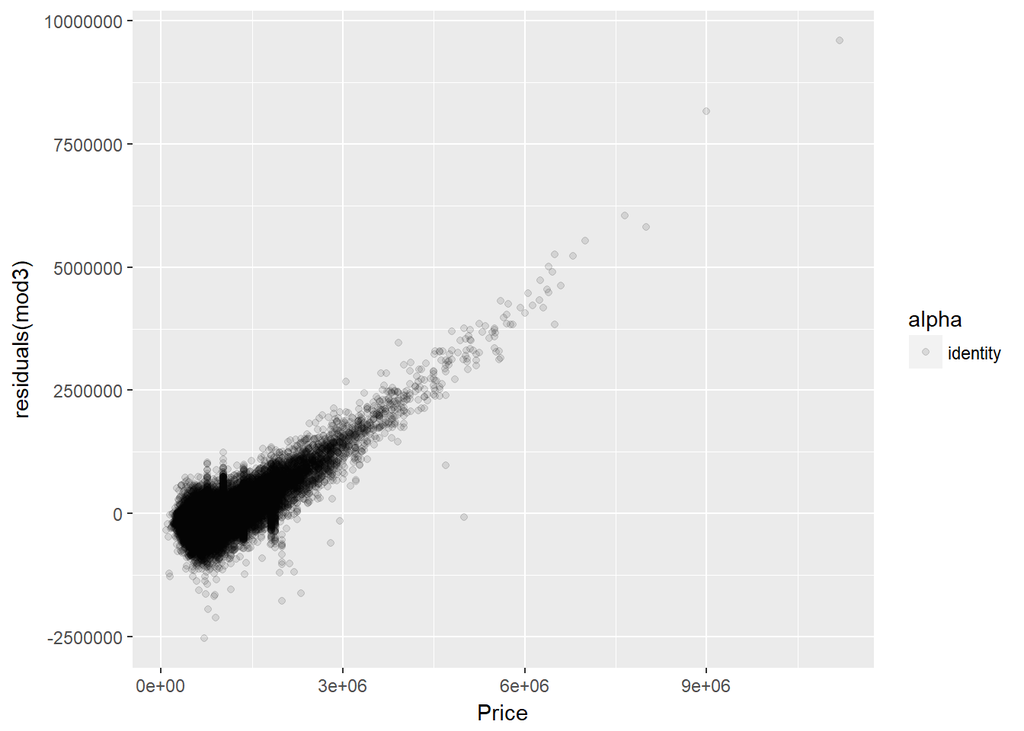

```r
ggplot(data=mod3, aes(x=Price,y=residuals(mod3),alpha="identity")) +
  geom_point()
```

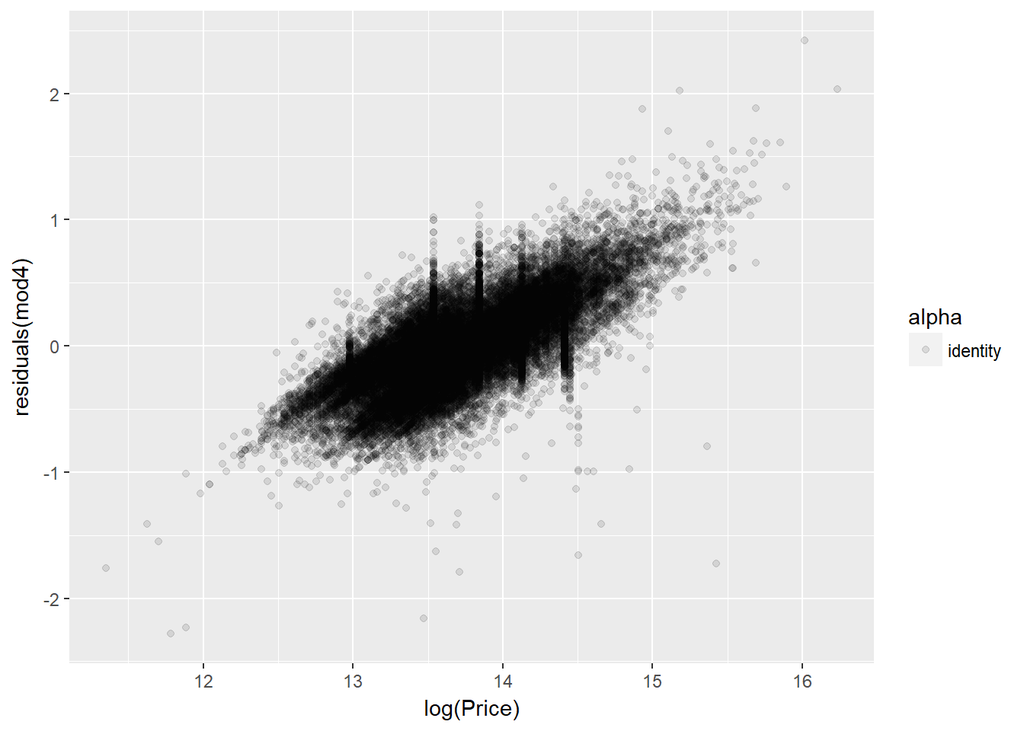

```r
ggplot(data=mod4, aes(x=`log(Price)`,y=residuals(mod4),alpha="identity")) +
  geom_point()
```